# Background

MNIST ("Modified National Institute of Standards and Technology") is a dataset comprised of handwritten images of digits from zero through nine. The goal of this assignment is to correctly identify the digit of each image. Therefore, this is a multiclass classification problem.

The MNIST data set is comprised of 42,000 digits and 784 columns (there is an additional column for the digit classification). Each image is 28 pixels in height and 28 pixels in width, for a total of 784 pixels, which corresponds to the 784 columns. The data within each column represents the lightness or darkness of each pixel.

The MNIST multiclass classifier is built sequentially. Random forest and principal component analysis (PCA) are used, and commentary is provided on the necessity of PCA for large data sets. Runtimes are recorded with results submitted to Kaggle for scoring.

# Data Initation

To begin this assignment, we start by reading in the data. Of note, data used for this assignment has already been split into training and test sets. The test set, however, does not have the final digit classification (response variable), as the predictions will be submitted to Kaggle for scoring.

```python
RANDOM_SEED = 42

# import packages
import pandas as pd
import numpy as np
import matplotlib.pyplot as plt
import seaborn as sns

# for model building and results
from sklearn.metrics import make_scorer, mean_squared_error, r2_score, mean_absolute_error, confusion_matrix, classification_report, roc_auc_score
from math import sqrt
from sklearn.model_selection import cross_validate, cross_val_score, cross_val_predict, train_test_split
from sklearn.preprocessing import StandardScaler
from sklearn.ensemble import RandomForestClassifier
from sklearn.decomposition import PCA
from sklearn.model_selection import GridSearchCV

# for display
from prettytable import PrettyTable

# misc
import time
```

```python
# read in the data
mnist_train = pd.read_csv('mnist_train.csv')
mnist_test = pd.read_csv('mnist_test.csv')
```

```python
# inspect the data
print("mnist_train shape: ", mnist_train.shape)
print("mnist_test shape: ", mnist_test.shape)
mnist_train.info()
mnist_train.columns
```

```
mnist_train shape:  (42000, 785)
mnist_test shape:  (28000, 784)
<class 'pandas.core.frame.DataFrame'>
RangeIndex: 42000 entries, 0 to 41999
Columns: 785 entries, label to pixel783
dtypes: int64(785)
memory usage: 251.5 MB
```

```
Index(['label', 'pixel0', 'pixel1', 'pixel2', 'pixel3', 'pixel4', 'pixel5',
       'pixel6', 'pixel7', 'pixel8',
       ...
       'pixel774', 'pixel775', 'pixel776', 'pixel777', 'pixel778', 'pixel779',
       'pixel780', 'pixel781', 'pixel782', 'pixel783'],
      dtype='object', length=785)
```

After reading in the data, we can better see that each column represents a pixel, and all columns are numeric.

We also check to see the distribution of digits and are hoping to see that the classes are fairly balanced. If they are not balanced, then during the model building process weights will be needed to ensure there is not bias toward one class.

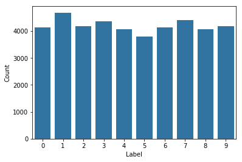

```python
current_palette = sns.color_palette() #10 colors
label_sum = mnist_train['label'].value_counts().to_frame('Count').rename_axis('Label').reset_index().sort_values('Label')
sns.barplot(x = 'Label', y = 'Count', data = label_sum, color = current_palette[0])
```

```python
# need to define X & y for model-building
X_train, y_train = mnist_train.loc[:, ~mnist_train.columns.isin(['label'])], mnist_train['label']
```

# Part One

We start the model building process by fitting a random forest classifier using all 784 variables.

To determine the hyperparameters for the random forest model, a grid search is performed. The default number of trees is used during tuning to help with time. Cross validation using 10 folds is used to determine the best hyperparameters.

```python
import warnings
warnings.simplefilter(action='ignore', category=FutureWarning)

rf_tune_start_time = time.time()

# fit random forest classifier
rf = RandomForestClassifier(random_state = RANDOM_SEED, n_jobs=-1)

# to speed up time, default n_estimators is used
param_grid = {
    'max_features': ['auto', 'log2'],
    'max_depth' : [5, 7, 10],
    'criterion' :['gini', 'entropy']
}

CV_rf = GridSearchCV(estimator = rf, param_grid = param_grid, cv = 10,
                     return_train_score = True)
CV_rf.fit(X_train, y_train)

# fit the model
rf1 = RandomForestClassifier(n_estimators = 200, max_features = CV_rf.best_params_['max_features'], max_depth = CV_rf.best_params_['max_depth'], criterion = CV_rf.best_params_['criterion'], bootstrap = True, random_state = RANDOM_SEED, n_jobs=-1)
rf1.fit(X_train, y_train)

# generate predictions
rf1_pred = rf1.predict(X_train)

rf_tune_elapsed_time = time.time() - rf_tune_start_time
```

```python
# share gof metrics
print("Precision, Recall, and F1 Score")
print(classification_report(y_train, rf1_pred))
print("_____________________________________________________")
print("Confusion Matrix")
print(confusion_matrix(y_train, rf1_pred))
```

```
Precision, Recall, and F1 Score
              precision    recall  f1-score   support

           0       0.99      0.99      0.99      4132
           1       0.98      0.99      0.98      4684
           2       0.98      0.97      0.97      4177
           3       0.97      0.96      0.97      4351
           4       0.97      0.96      0.97      4072
           5       0.99      0.98      0.98      3795
           6       0.98      0.99      0.99      4137
           7       0.97      0.96      0.97      4401
           8       0.98      0.97      0.97      4063
           9       0.93      0.95      0.94      4188

   micro avg       0.97      0.97      0.97     42000
   macro avg       0.97      0.97      0.97     42000
weighted avg       0.97      0.97      0.97     42000

_____________________________________________________
Confusion Matrix
[[4103    0    0    0    4    0   11    0   14    0]
 [   0 4637   10    9    8    1    5    7    5    2]
 [   2   11 4059    6   19    0   17   39   14   10]
 [   0    8   34 4192    4   30    6   31   25   21]
 [   1    4    0    0 3925    0   11    8    4  119]
 [   4    9    2   27    5 3707   14    2   12   13]
 [   8    8    1    0    5    5 4105    0    5    0]
 [   1   24   41    1   17    1    0 4237    7   72]
 [   1   26    6    9   10    2    6    5 3951   47]
 [  11   10    3   63   39    3    2   45   15 3997]]
```

```python
# generate test set predictions
rf_predictions_start_time = time.time()
rf_predictions = rf1.predict(mnist_test)
rf_predictions_elapsed_time = time.time() - rf_predictions_start_time
#rf_predictions[:10]
```

```python
# make sure predictions are in right format
rf_predictions = pd.DataFrame(rf_predictions, columns = ["Label"])
rf_predictions['ImageId'] = range(1, len(rf_predictions) + 1)
cols = rf_predictions.columns.tolist()
cols = cols[-1:] + cols[:-1]
rf_predictions = rf_predictions[cols]
```

```python
# calculate total rf time
total_rf_elapsed_time = rf_tune_elapsed_time + rf_predictions_elapsed_time
total_rf_elapsed_time
```

```
235.90052771568298
```

```python
# export results
rf_predictions.to_csv("mnist_predictions_m1.csv", index=False)
```

# Part Two

We utilize principal components analysis (PCA) on the combined training set to generate principal components that capture 95 percent of the variability from the original data.

```python
pca_start_time = time.time()
pca = PCA(n_components=.95, random_state = RANDOM_SEED)
X_reduced = pca.fit_transform(X_train)
X_test_pca = pca.transform(mnist_test) # we do this now for later
pca_elapsed_time = time.time() - pca_start_time
```

```python
# check number of pc's
pca_df = pd.DataFrame(X_reduced)
pca_df.shape # see that there are 154 PCs
```

```
(42000, 154)
```

From the code above, we can see that after applying PCA techniques, we are left with 154 principal components. This result is a significant reduction from the 784 original variables. Therefore, building a model should go much quicker.

```python
# report pca time
pca_elapsed_time
```

```
8.69625210762024
```

# Part Three

In this section, we utilize the 154 principal components identified above to build another random forest classifier. Like in Part One, a grid search with 10-fold cross validation is used to determine the optimal hyperparameters.

```python
rf_tune_start_time2 = time.time()

# fit random forest classifier
rf = RandomForestClassifier(random_state = RANDOM_SEED, n_jobs=-1)

# to speed up time, default n_estimators is used
param_grid = {
    'max_features': ['auto', 'log2'],
    'max_depth' : [5, 7, 10],
    'criterion' :['gini', 'entropy']
}

CV_rf2 = GridSearchCV(estimator = rf, param_grid = param_grid, cv = 10,
                     return_train_score=True)
CV_rf2.fit(X_reduced, y_train)

# fit the model using best params
rf2 = RandomForestClassifier(n_estimators = 200, max_features = CV_rf2.best_params_['max_features'], max_depth = CV_rf2.best_params_['max_depth'], criterion = CV_rf2.best_params_['criterion'], bootstrap = True, random_state = RANDOM_SEED, n_jobs=-1)
rf2.fit(X_reduced, y_train)

# generate predictions
rf2_pred = rf2.predict(X_reduced)

rf_tune_elapsed_time2 = time.time() - rf_tune_start_time2
```

```python
# share gof metrics
print("Precision, Recall, and F1 Score")
print(classification_report(y_train, rf2_pred))
print("_____________________________________________________")
print("Confusion Matrix")
print(confusion_matrix(y_train, rf2_pred))
```

```
Precision, Recall, and F1 Score
              precision    recall  f1-score   support

           0       0.99      0.99      0.99      4132
           1       0.98      0.99      0.99      4684
           2       0.96      0.96      0.96      4177
           3       0.95      0.96      0.95      4351
           4       0.98      0.97      0.97      4072
           5       0.98      0.97      0.98      3795
           6       0.98      0.99      0.98      4137
           7       0.97      0.97      0.97      4401
           8       0.95      0.95      0.95      4063
           9       0.96      0.95      0.96      4188

   micro avg       0.97      0.97      0.97     42000
   macro avg       0.97      0.97      0.97     42000
weighted avg       0.97      0.97      0.97     42000

_____________________________________________________
Confusion Matrix
[[4084    0    4    5    2    3   19    1   12    2]
 [   0 4625   15   14    1    5    9    4   10    1]
 [  10   10 4007   25   10    2    3   27   78    5]
 [   4    1   52 4174    2   14    4   20   54   26]
 [   2    9   13    0 3964    1   11    4    8   60]
 [  10    0    2   35    6 3698   22    4   13    5]
 [  13    1    4    0    4   17 4093    0    5    0]
 [   0   26   40    1   11    0    0 4270   15   38]
 [   5   22   17   76   16   33   13    9 3851   21]
 [   7    6    4   66   44    7    1   51   28 3974]]
```

```python
# generate test set predictions
rf_predictions_start_time2 = time.time()
rf_predictions2 = rf2.predict(X_test_pca)
rf_predictions_elapsed_time2 = time.time() - rf_predictions_start_time2
```

```python
# make sure predictions are in right format
rf_predictions2 = pd.DataFrame(rf_predictions2, columns = ["Label"])
rf_predictions2['ImageId'] = range(1, len(rf_predictions2) + 1)
cols = rf_predictions2.columns.tolist()
cols = cols[-1:] + cols[:-1]
rf_predictions2 = rf_predictions2[cols]
```

```python
# share total time
rf_pca_total_time = rf_tune_elapsed_time2 + rf_predictions_elapsed_time2
rf_pca_total_time
```

```
501.9884798526764
```

```python
# export results
rf_predictions2.to_csv("mnist_predictions_m2.csv", index=False)
```

# Part Four

The results of the Kaggle submission (username = juliarodd) for the Random Forest model are an accuracy of: 0.94714.

The results of the Kaggle submission (username = juliarodd) for PCA Random Forest model are an accuracy of: 0.92485. Therefore, this model has done worse than the Random Forest model with all 784 variables.

# Part Five

While the intent of using PCA is to reduce the number of variables considered in the model, there is a flaw with the approach that has been taken thus far. PCA requires that the data be standardized. If the data is not standardized, then more weight is given to variables that have greater variable. Since PCA is a technique that projects the original data in a way that maximizes variance, without standardizing the variables beforehand, the resulting principal components are biased toward variables with high variance. Therefore, standardizing variables ensure that PCA techniques return a stable and non biased solution.

```python
from sklearn.exceptions import DataConversionWarning
warnings.simplefilter(action='ignore', category=DataConversionWarning)

revised_start_time = time.time()

# data needs to be scaled first!
scaler = StandardScaler()
scaler.fit(X_train)
X_scaled = scaler.transform(X_train)
test_scaled = scaler.transform(mnist_test) # scale the test set using scaler from training

# generate PCs
pca2 = PCA(n_components=.95, random_state = RANDOM_SEED)
pca2.fit(X_scaled)
X_reduced = pca2.transform(X_scaled)

# fit random forest classifier
rf = RandomForestClassifier(random_state = RANDOM_SEED, n_jobs=-1)

param_grid = {
    'max_features': ['auto', 'log2'],
    'max_depth' : [5, 7, 10],
    'criterion' :['gini', 'entropy']
}

CV_rf3 = GridSearchCV(estimator = rf, param_grid = param_grid, cv = 10,
                     return_train_score=True)
CV_rf3.fit(X_reduced, y_train)

# define the model
rf3 = RandomForestClassifier(n_estimators = 200, max_features = CV_rf3.best_params_['max_features'], max_depth = CV_rf3.best_params_['max_depth'], criterion = CV_rf3.best_params_['criterion'], bootstrap = True, random_state = RANDOM_SEED, n_jobs=-1)
rf3.fit(X_reduced, y_train)

# generate predictions
rf3_pred = rf3.predict(X_reduced)

revised_elapsed_time = time.time() - revised_start_time
```

```python
# share gof metrics
print("Precision, Recall, and F1 Score")
print(classification_report(y_train, rf3_pred))
print("_____________________________________________________")
print("Confusion Matrix")
print(confusion_matrix(y_train, rf3_pred))
```

```
Precision, Recall, and F1 Score
              precision    recall  f1-score   support

           0       0.98      0.99      0.98      4132
           1       0.98      0.99      0.98      4684
           2       0.97      0.97      0.97      4177
           3       0.92      0.96      0.94      4351
           4       0.96      0.97      0.97      4072
           5       0.97      0.93      0.95      3795
           6       0.97      0.98      0.98      4137
           7       0.97      0.96      0.96      4401
           8       0.96      0.94      0.95      4063
           9       0.94      0.94      0.94      4188

   micro avg       0.96      0.96      0.96     42000
   macro avg       0.96      0.96      0.96     42000
weighted avg       0.96      0.96      0.96     42000

_____________________________________________________
Confusion Matrix
[[4083    0    3    6    1    5   19    1   14    0]
 [   1 4615   21   15    2    1   14    4   10    1]
 [  13    6 4039   26   15    1    7   18   47    5]
 [   5    6   28 4181    5   14    7   24   56   25]
 [   1   16   13    0 3950    4    8    5    6   69]
 [  11    0   10  120   12 3539   52    5   17   29]
 [  19    4    2    0    6   33 4066    0    7    0]
 [   7   25   20   13   24    0    0 4211    2   99]
 [  13   35   13  101   12   30   19    7 3802   31]
 [  13    4    8   62   69    7    0   61   19 3945]]
```

```python
rf_predictions_start_time3 = time.time()
# transform test set
X_test_pca2 = pca2.transform(test_scaled)

# generate predictions
final_rf_pred = rf3.predict(X_test_pca2)
rf_predictions_elapsed_time3 = time.time() - rf_predictions_start_time3
```

```python
# share total time
total_revised_elapsed_time = revised_elapsed_time + rf_predictions_elapsed_time3
total_revised_elapsed_time
```

```
693.1889712810516
```

```python
# make sure predictions are in right format
final_rf_pred = pd.DataFrame(final_rf_pred, columns = ["Label"])
final_rf_pred['ImageId'] = range(1, len(final_rf_pred) + 1)
cols = final_rf_pred.columns.tolist()
cols = cols[-1:] + cols[:-1]
final_rf_pred = final_rf_pred[cols]
```

```python
# export results
final_rf_pred.to_csv("mnist_predictions_m3.csv", index=False)
```

The results of the Kaggle submission (username = juliarodd) for this model are an accuracy of: 0.91428. Thus, this model has performed the worst out of all the models.

# Summary and Conclusions

In summary, this assignment generated three different multiclassification models on the MNIST data set. While the model using the original/raw 784 variables performed the best, this model lacks scalability in the long run. Interestingly, the model that did not scale/standardize the data before appyling PCA techniques performed slightly better than the model that did standardize and apply PCA. Because implementing PCA is a variable reduction technique (that aims to maximize variability), we would not expect the PCA models to perform better than models with the original variables. Rather, by using less variables, there is greater flexibility in the machine learning algorithms that can be considered. As one example, hyperparameter tuning becomes a much quicker process when there are significantly less variables involved. Although the results above did not explicitly shown time savings when implementing PCA properly, if additional models were considered, then the time savings would be realized.

Therefore, PCA should be implemented as a preliminary step to machine learning classification problems when there are a significant number of variables involved. PCA has the benefit of reducing the number of variables considered in the model, which is a helpful step with extremely large (i.e., big data) datasets. While this step may make the model more complicated to explain to stakeholders, it ensures that the end model used still has high performance using as few variables as possible. This result is in line with the principle of parsimony.

To help improve model results, the parameter tuning grid should be expanded and varied across all models. Additionally, weights could be implemented to help further balance the results across all the classes. While the class distribution was fairly even, it was not perfectly even, and this step would help ensure that the model is not biased toward certain numbers. Furthermore, additional models could be considered outside of random forests. For instance, gradient tree boosting could be considered with results compared to a random forest model to determine which model is truly best for this business problem. Lastly, if more time allowed, visuals of the predicted images could be rendered across the models to offer another perspective of model performance.